# HUDK4051: Prediction - Comparing Trees

Zach Friedman

2/25/2021

*In this assignment you will be modelling student data using three flavors of tree algorithm: CART, C4.5 and C5.0. We will be using these algorithms to attempt to predict which students drop out of courses. Many universities have a problem with students over-enrolling in courses at the beginning of semester and then dropping most of them as the make decisions about which classes to attend. This makes it difficult to plan for the semester and allocate resources. However, schools don’t want to restrict the choice of their students. One solution is to create predictions of which students are likely to drop out of which courses and use these predictions to inform semester planning.*

*In this assignment we will be using the tree algorithms to build models of which students are likely to drop out of which classes.*

## Software

*In order to generate our models we will need several packages. The first package you should install is [caret](https://cran.r-project.org/web/packages/caret/index.html).*

*There are many prediction packages available and they all have slightly different syntax. caret is a package that brings all the different algorithms under one hood using the same syntax.*

*We will also be accessing an algorithm from the [Weka suite](https://www.cs.waikato.ac.nz/~ml/weka/). Weka is a collection of machine learning algorithms that have been implemented in Java and made freely available by the University of Waikato in New Zealand. To access these algorithms you will need to first install both the [Java Runtime Environment (JRE) and Java Development Kit](http://www.oracle.com/technetwork/java/javase/downloads/jre9-downloads-3848532.html) on your machine. You can then then install the [RWeka](https://cran.r-project.org/web/packages/RWeka/index.html) package within R.*

*Weka requires Java and Java causes problems. If you cannot install Java and make Weka work, please follow the alternative instructions at line 121* *(Issue 1: failure to install RWeka/RWekajars, paste “sudo R CMD javareconf” into terminal and try to install again)*

*The last package you will need is [C50](https://cran.r-project.org/web/packages/C50/index.html).*

```r
library(C50)
library(caret)
library(RWeka)
library(tidyverse)
library(GGally)
library(lubridate)
library(party)
```

## Data

*The data comes from a university registrar’s office. The code book for the variables are available in the file code-book.txt. Examine the variables and their definitions.*

*Upload the drop-out.csv data into R as a data frame.*

```r
drop_out <- read.csv("drop-out.csv")
```

*The next step is to separate your data set into a training set and a test set. Randomly select 25% of the students to be the test data set and leave the remaining 75% for your training data set. (Hint: each row represents an answer, not a single student.)*

```r
set.seed(652)
drop_out <- drop_out %>% mutate(student_id = as.factor(student_id), course_id = as.factor(course_id), gender = as.factor(gender),enroll_date_time = as.POSIXct(enroll_date_time, origin = "2010-01-01", tz = "GMT"),complete = factor(complete, levels = c("no","yes")),international = factor(international, levels = c("no","yes")), online = factor(online, levels = c("no","yes"))) #origin is assumed to be 2010 arbitrarily because no information is provided in the codebook


perc_75 <- (unique(drop_out$student_id) %>% length) * .75 #How many students are there, find 75% of this number
perc_75 <- perc_75 %>% round
train_ids <- sample(unique(drop_out$student_id))[1:perc_75]

drop_out <- drop_out %>% mutate(type = ifelse(student_id %in% train_ids, "train", "test"))
drop_out_train <- drop_out %>% filter(type == "train")
drop_out_test <- drop_out %>% filter(type == "test")
```

*For this assignment you will be predicting the student level variable “complete”.* *(Hint: make sure you understand the increments of each of your chosen variables, this will impact your tree construction)*

*Visualize the relationships between your chosen variables as a scatterplot matrix. Save your image as a .pdf named scatterplot_matrix.pdf.*

**Based on this visualization do you see any patterns of interest? Why or why not?**

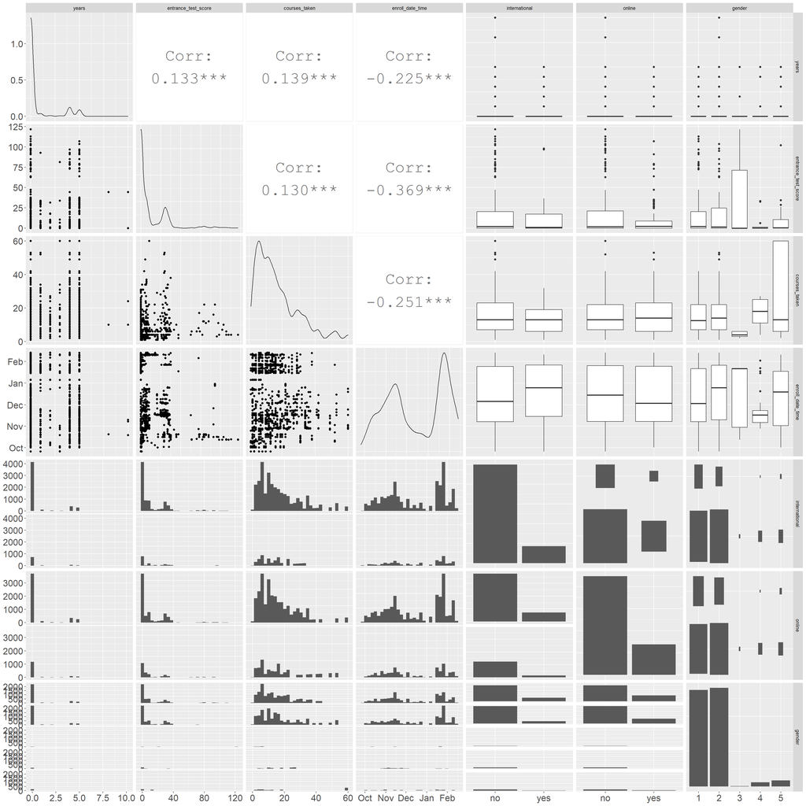

```r
ggpairs(drop_out %>% select(-type,-student_id,-course_id,-complete), progress = F,upper = list(continuous = wrap("cor", size=10))) + theme(axis.text.x = element_text(size = 16),axis.text.y = element_text(size = 16),plot.title = element_text(size = 1))
```

When looking at relationships between continuous variables, there are three variables to analyze:

1. Entrance test score
2. Courses taken
3. Date of enrollment

The correlation between each pair of these three variables is significant in every case. The most significant relationship is between entrance test score and time of enrollment (r = -.369). This makes sense because the higher score someone gets on an entrance exam, the more prepared they are for a class and the more likely they are to have a higher number of credits entering University. Colleges often schedule registration dates by number of credits; students with more credits can schedule first.

For the same reason, it is also sensible why there would be a negative correlation between courses taken and date of enrollment and why there would be a positive relationship between entrance test score and courses taken.

None of the categorical variables stand out as having interesting relationships solely based on the small graphs in the matrix, except for the gender and enrollment date pair.

It is unintuitive why there would be significantly different median enrollment dates for each of the 5 genders. Although there are few people classified in genders “3”, “4”, and “5” which may result in purely, statistical higher variability, genders 1 and 2 were different as well. Perhaps males and females have different rates of registration for particular semesters at this college. There also could be a confounding effect of international/online registration (since there is an unequal gender distribution for these variables) with registration time.

## CART Trees

*You will use the [rpart package](https://cran.r-project.org/web/packages/rpart/rpart.pdf) to generate CART tree models.*

*Construct a classification tree that predicts complete using the caret package.*

```r
TRAIN1 <- drop_out_train %>% select(-type)

TRAIN2 <- TRAIN1[,c(2:10)] #Remove the student_id variable that we do not want to use in the model

#caret does not summarize the metrics we want by default so we have to modify the output
MySummary  <- function(data, lev = NULL, model = NULL){
  df <- defaultSummary(data, lev, model)
  tc <- twoClassSummary(data, lev, model)
  pr <- prSummary(data, lev, model)
  out <- c(df,tc,pr)
  out}

#Define the control elements we would like to use
ctrl <- trainControl(method = "repeatedcv", #Tell caret to perform k-fold cross validation
                repeats = 3, #Tell caret to repeat each fold three times
                classProbs = TRUE, #Calculate class probabilities
                summaryFunction = MySummary)

#Define the model
cartFit <- train(complete ~ ., #Define which variable to predict
                data = TRAIN2, #Define the data set to train the model on
                trControl = ctrl, #Tell caret the control elements
                method = "rpart", #Define the model type
                metric = "Accuracy", #Final model choice is made according to sensitivity
                preProc = c("center", "scale")) #Center and scale the data to minimize the

#Check the results
cartFit$finalModel
```

```
## n= 4431
##
## node), split, n, loss, yval, (yprob)
##       * denotes terminal node
##
##   1) root 4431 1325 yes (0.29902956 0.70097044)
##     2) years>=-0.1049275 756    0 no (1.00000000 0.00000000) *
##     3) years< -0.1049275 3675  569 yes (0.15482993 0.84517007)
##       6) courses_taken< -1.062712 259  117 yes (0.45173745 0.54826255)
##        12) course_id658463>=1.109077 42    1 no (0.97619048 0.02380952) *
##        13) course_id658463< 1.109077 217   76 yes (0.35023041 0.64976959)
##          26) courses_taken< -1.222134 16    0 no (1.00000000 0.00000000) *
##          27) courses_taken>=-1.222134 201   60 yes (0.29850746 0.70149254)
##            54) course_id807728< 1.62686 135   60 yes (0.44444444 0.55555556)
##             108) course_id807717< 1.57819 73   14 no (0.80821918 0.19178082) *
##             109) course_id807717>=1.57819 62    1 yes (0.01612903 0.98387097) *
##            55) course_id807728>=1.62686 66    0 yes (0.00000000 1.00000000) *
##       7) courses_taken>=-1.062712 3416  452 yes (0.13231850 0.86768150) *
```

```r
cartFit
```

```
## CART
##
## 4431 samples
##    8 predictor
##    2 classes: 'no', 'yes'
##
## Pre-processing: centered (44), scaled (44)
## Resampling: Cross-Validated (10 fold, repeated 3 times)
## Summary of sample sizes: 3989, 3988, 3989, 3988, 3988, 3987, ...
## Resampling results across tuning parameters:
##
##   cp           Accuracy   Kappa      ROC        Sens       Spec       AUC
##   0.003018868  0.8924296  0.7151178  0.8307792  0.6490639  0.9962455  0.2676902
##   0.015094340  0.8789595  0.6736072  0.8038744  0.6012284  0.9974256  0.2805026
##   0.570566038  0.7754280  0.2872510  0.6244608  0.2489215  1.0000000  0.1414371
##   Precision  Recall     F
##   0.9866567  0.6490639  0.7824162
##   0.9908257  0.6012284  0.7464278
##   1.0000000  0.2489215  0.6953319
##
## Accuracy was used to select the optimal model using the largest value.
## The final value used for the model was cp = 0.003018868.
```

**Describe important model attribues of your tree. Do you believe it is a successful model of student performance, why/why not?**

The final model has several branches with many variables directing the classification: years, course_id of 3 different courses, and total courses taken. It is hard to interpret the cutoff points for each of the variables because the data were centered and scaled.

However, it is clear that having been enrolled in a program at the University for a longer period of time before taking a course is an excellent predictor of completion, with more years resulting in an incredibly low chance of completion. These might be students who are retaking a course because they struggled first taking it or they might not belong in the course and accidentally enroll and then later drop the course.

Courses 658463, 807717, and 807728 are key courses in that they were almost universally passed or failed or that once accounting for other tree branchings, like courses taken, the course id was an essential factor in predicting completion.

I believe the model is mixed in its ability to predict student performance. Although the accuracy was over 89%, the sensitivity and specificity of the model were quite different.

The specificity was over 99%, meaning there were very few false predictions of incompletion for students who did in fact complete the course.

However, the sensitivity was just 65%, meaning there were many students who failed to complete a course but they were incorrectly predicted to complete the course. Thus, the model could be used to set an upper bound on the number of students that will actually stay in the course, but it does not score extremely well in identifying which students will drop a course, only identifying them about two-thirds of the time.

**Can you use the sensitivity and specificity metrics to calculate the F1 metric?**

Yes, using sensitivity, specificity, accuracy, and precision, there are four unknowns and 4 equations. Thus, the system of equations is solvable. Another formula to calculate F1 is shown below.

$F1 = \frac{2*sensitivity*precision}{sensitivity + precision}$

**Now predict results from the test data and describe important attributes of this test. Do you believe it is a successful model of student performance, why/why not?**

```r
drop_out_test <- drop_out_test %>% select(-type)
TEST1 <- drop_out_test
TEST2 <- TEST1[,c(2:10)] #Remove the student_id variable that we do not want to use in the model

#Generate prediction using previously trained model
cartClasses <- predict(cartFit, newdata = TEST2)

#Generate model statistics
confusionMatrix(data = cartClasses, as.factor(TEST2$complete))
```

```
## Confusion Matrix and Statistics
##
##           Reference
## Prediction   no  yes
##        no   272    2
##        yes  127 1029
##
##                Accuracy : 0.9098
##                  95% CI : (0.8937, 0.9241)
##     No Information Rate : 0.721
##     P-Value [Acc > NIR] : < 2.2e-16
##
##                   Kappa : 0.752
##
##  Mcnemar's Test P-Value : < 2.2e-16
##
##             Sensitivity : 0.6817
##             Specificity : 0.9981
##          Pos Pred Value : 0.9927
##          Neg Pred Value : 0.8901
##              Prevalence : 0.2790
##          Detection Rate : 0.1902
##    Detection Prevalence : 0.1916
##       Balanced Accuracy : 0.8399
##
##        'Positive' Class : no
##
```

After seeing the model tested on the test data, the conclusions are the same. The model is mixed in its ability to predict student performance. The accuracy is still about 90%, but the sensitivity and specificity of the model were quite different.

The specificity was still over 99%, meaning there were very few false predictions of incompletion for students who did in fact complete the course (just 2 out of 1031).

However, the sensitivity was just 68%. There were 127 students (out of 399) who failed to complete the course, but they were incorrectly predicted to complete the course. If the model was used to set an upper bound on the number of students that will actually stay in courses, it would predict 1156, whereas only 1031 actually did stay. If this inflation of about 10% is consistent over a lot of semesters then that could be factored into the estimate to make it more accurate.

## Conditional Inference Trees

*Train a Conditional Inference Tree using the `party` package on the same training data and examine your results.*

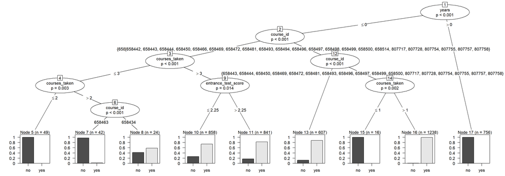

```r
TRAIN3 <- TRAIN2 %>% select(-enroll_date_time)

condFit <- ctree(complete ~.,TRAIN3) #the data were not scaled or normalized because it hindered and interpretability, and accuracy was high without such pre-processing

plot(condFit, tp_args = list(beside = TRUE))
```

**Describe important model attributes of your tree.**

The model has several branches with many variables directing the classification: years, entrance test score, total courses taken, and course_id.

Similarly to the CART model, it is clear that having been enrolled in a program at the University for a longer period of time before taking a course is an excellent predictor of completion, with more years resulting in zero chance of completion.

Without the scaling of variables, the model did not turn course_id into dummy variables. Thus, this model was collectively exhaustive in using course titles when it appeared as a decision branch in the tree.

Entrance test score was not an attribute of the CART model but was in this model. It appears just once as a final decision node, but it does end up slightly impacting the probability of completion of about 1700 students in the train data.

**Do you believe it is a successful model of student performance, why/why not?**

Similarly to the CART model, I believe the model is mixed in its ability to predict student performance. Although the accuracy was over 90%, the sensitivity was again lacking.

The specificity was actually 100%, meaning there were zero false predictions of incompletion for students who did in fact complete the course.

The sensitivity was again just 66%, meaning there were many students who failed to complete a course but they were incorrectly predicted to complete the course.

**What does the plot represent? What information does this plot tell us?**

The plot represents the decision tree created by the model. At the terminal nodes, the bar graphs indicate how many students in that node completed the course and how many did not. There are a few terminal nodes where there are almost all student of one completion type (yes or no). For example, when years in the program is greater than 0, no students completed the course. Some decision nodes only result in slight differences in the percentage of students who completed the course, e.g. entrance test scores of greater than 2.25 slightly increase the likelihood of course completion.

*Now test your new Conditional Inference model by predicting the test data and generating model fit statistics.*

```r
#Generate prediction using previously trained model
cartClasses <- predict(condFit, newdata = TEST2)

#Generate model statistics
confusionMatrix(data = cartClasses, as.factor(TEST2$complete))
```

```
## Confusion Matrix and Statistics
##
##           Reference
## Prediction   no  yes
##        no   266    0
##        yes  133 1031
##
##                Accuracy : 0.907
##                  95% CI : (0.8907, 0.9215)
##     No Information Rate : 0.721
##     P-Value [Acc > NIR] : < 2.2e-16
##
##                   Kappa : 0.7425
##
##  Mcnemar's Test P-Value : < 2.2e-16
##
##             Sensitivity : 0.6667
##             Specificity : 1.0000
##          Pos Pred Value : 1.0000
##          Neg Pred Value : 0.8857
##              Prevalence : 0.2790
##          Detection Rate : 0.1860
##    Detection Prevalence : 0.1860
##       Balanced Accuracy : 0.8333
##
##        'Positive' Class : no
##
```

*There is an updated version of the C4.5 model called C5.0, it is implemented in the C50 package.*

**What improvements have been made to the newer version?**

1. The C5.0 algorithm has higher accuracy
2. C5.0 is faster, creating trees more quickly by orders of magnitude
3. The memory required for C5.0 is about 10 times less than that of C4.5
4. More data types, including dates and case labels, can be handled
5. Sampling and cross-validation are easier to integrate

Source: https://rulequest.com/see5-comparison.html

## C50 Tree

*Install the C50 package, train and then test the C5.0 model on the same data.*

```r
c50Fit <- C5.0(TRAIN2[,-4] %>% mutate(enroll_date_time = as.numeric(enroll_date_time)), TRAIN2[,4]) #Posix date format must be converted back to numeric for C5.0


c50Fit %>% summary
```

```
##
## Call:
## C5.0.default(x = TRAIN2[, -4] %>% mutate(enroll_date_time
##  = as.numeric(enroll_date_time)), y = TRAIN2[, 4])
##
##
## C5.0 [Release 2.07 GPL Edition]      Fri Feb 26 14:42:51 2021
## -------------------------------
##
## Class specified by attribute `outcome'
##
## Read 4431 cases (9 attributes) from undefined.data
##
## Decision tree:
##
## years > 0: no (756)
## years <= 0:
## :...courses_taken > 3: yes (3416/452)
##     courses_taken <= 3:
##     :...course_id in {658434,658463}: no (115/15)
##         course_id in {658438,658439,658440,658441,658442,658443,658444,658445,
##                       658450,658464,658465,658466,658467,658468,658469,658470,
##                       658472,658481,658493,658494,658495,658496,658497,658498,
##                       658499,658500,658514,807717,807728,807754,807755,807757,
##                       807758}: yes (144/17)
##
##
## Evaluation on training data (4431 cases):
##
##      Decision Tree
##    ----------------
##    Size      Errors
##
##       4  484(10.9%)   <<
##
##
##     (a)   (b)    <-classified as
##    ----  ----
##     856   469    (a): class no
##      15  3091    (b): class yes
##
##
##  Attribute usage:
##
##  100.00% years
##   82.94% courses_taken
##    5.85% course_id
##
##
## Time: 0.0 secs
```

```r
#Generate prediction using previously trained model
cartClasses <- predict(c50Fit, newdata = TEST2 %>% mutate(enroll_date_time = as.numeric(enroll_date_time)))

#Generate model statistics
confusionMatrix(data = cartClasses, as.factor(TEST2$complete))
```

```
## Confusion Matrix and Statistics
##
##           Reference
## Prediction   no  yes
##        no   270    2
##        yes  129 1029
##
##                Accuracy : 0.9084
##                  95% CI : (0.8922, 0.9228)
##     No Information Rate : 0.721
##     P-Value [Acc > NIR] : < 2.2e-16
##
##                   Kappa : 0.7477
##
##  Mcnemar's Test P-Value : < 2.2e-16
##
##             Sensitivity : 0.6767
##             Specificity : 0.9981
##          Pos Pred Value : 0.9926
##          Neg Pred Value : 0.8886
##              Prevalence : 0.2790
##          Detection Rate : 0.1888
##    Detection Prevalence : 0.1902
##       Balanced Accuracy : 0.8374
##
##        'Positive' Class : no
##
```

## Compare the models

```r
#models need to be redone using caret package so that object types are the same for resampling comparison

condFit <- train(complete ~ ., #Define which variable to predict
                data = TRAIN2, #Define the data set to train the model on
                trControl = ctrl, #Tell caret the control elements
                method = "ctree", #Define the model type
                metric = "Accuracy", #Final model choice is made according to sensitivity
                preProc = c("center", "scale")) #Center and scale the data to minimize the

c50Fit <- train(complete ~ ., #Define which variable to predict
                data = TRAIN2, #Define the data set to train the model on
                trControl = ctrl, #Tell caret the control elements
                method = "C5.0", #Define the model type
                metric = "Accuracy", #Final model choice is made according to sensitivity
                preProc = c("center", "scale")) #Center and scale the data to minimize the
```

*Caret allows us to compare all three models at once.*

```r
resamps <-resamples(list(cart = cartFit, condinf = condFit, cfiveo = c50Fit))

summary(resamps)
```

```
##
## Call:
## summary.resamples(object = resamps)
##
## Models: cart, condinf, cfiveo
## Number of resamples: 30
##
## Accuracy
##              Min.   1st Qu.    Median      Mean   3rd Qu.      Max. NA's
## cart    0.8693694 0.8831828 0.8927785 0.8924296 0.9022055 0.9209932    0
## condinf 0.8755656 0.8871332 0.8963964 0.8940762 0.9022055 0.9117647    0
## cfiveo  0.8668172 0.8871332 0.8939047 0.8941555 0.9000015 0.9255079    0
##
## AUC
##              Min.   1st Qu.    Median      Mean   3rd Qu.      Max. NA's
## cart    0.1872198 0.2436333 0.2607167 0.2676902 0.2877281 0.3418738    0
## condinf 0.1950682 0.2247824 0.2576724 0.2524922 0.2729280 0.3138341    0
## cfiveo  0.1552387 0.2031575 0.2211048 0.2239553 0.2445982 0.3451518    0
##
## F
##              Min.   1st Qu.    Median      Mean   3rd Qu.      Max. NA's
## cart    0.7211538 0.7595853 0.7836032 0.7824162 0.8045228 0.8484848    0
## condinf 0.7368421 0.7674269 0.7909091 0.7849639 0.8045228 0.8266667    0
## cfiveo  0.7203791 0.7690494 0.7883117 0.7870238 0.8031191 0.8595745    0
##
## Kappa
##              Min.   1st Qu.    Median      Mean   3rd Qu.      Max. NA's
## cart    0.6443192 0.6878902 0.7163498 0.7151178 0.7427331 0.7966957    0
## condinf 0.6625954 0.6980431 0.7259921 0.7189284 0.7427331 0.7698470    0
## cfiveo  0.6400705 0.6991490 0.7216312 0.7204657 0.7388802 0.8100763    0
##
## Precision
##              Min.   1st Qu.    Median      Mean   3rd Qu. Max. NA's
## cart    0.9411765 0.9800973 0.9889499 0.9866567 1.0000000    1    0
## condinf 0.9578947 1.0000000 1.0000000 0.9966867 1.0000000    1    0
## cfiveo  0.9565217 0.9776516 0.9882353 0.9836608 0.9900697    1    0
##
## Recall
##              Min.   1st Qu.    Median      Mean   3rd Qu.      Max. NA's
## cart    0.5639098 0.6143626 0.6515152 0.6490639 0.6742424 0.7368421    0
## condinf 0.5833333 0.6252421 0.6541353 0.6480197 0.6742424 0.7045455    0
## cfiveo  0.5757576 0.6287879 0.6566131 0.6570669 0.6818182 0.7593985    0
##
## ROC
##              Min.   1st Qu.    Median      Mean   3rd Qu.      Max. NA's
## cart    0.7776999 0.8212410 0.8306285 0.8307792 0.8415996 0.8735144    0
## condinf 0.8796507 0.8942892 0.9010965 0.9039766 0.9130554 0.9351051    0
## cfiveo  0.7830556 0.8131338 0.8269747 0.8261725 0.8375830 0.8780863    0
##
## Sens
##              Min.   1st Qu.    Median      Mean   3rd Qu.      Max. NA's
## cart    0.5639098 0.6143626 0.6515152 0.6490639 0.6742424 0.7368421    0
## condinf 0.5833333 0.6252421 0.6541353 0.6480197 0.6742424 0.7045455    0
## cfiveo  0.5757576 0.6287879 0.6566131 0.6570669 0.6818182 0.7593985    0
##
## Spec
##              Min.   1st Qu.    Median      Mean   3rd Qu. Max. NA's
## cart    0.9839228 0.9943704 0.9967846 0.9962455 1.0000000    1    0
## condinf 0.9871383 1.0000000 1.0000000 0.9990343 1.0000000    1    0
## cfiveo  0.9870968 0.9935484 0.9967742 0.9952782 0.9967846    1    0
```

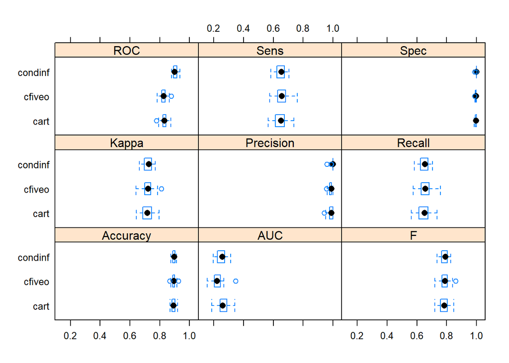

```r
bwplot(resamps)
```

**What does the model summary tell us?**

The summary gives the distributions of the accuracy, ROC, sensitivity, specificity, and other model metrics for each of the three models with 30 resamplings.

**Which model do you believe is the best?**

The three models are extremely similar in all model performance measures. However, the conditional inference model had the highest median value in a plurality of categories. Notably, the first quartile specificity and precision were both 1.00 for the CondInf model. It also had the smallest interquartile range for a plurality of the categories, meaning it was the most consistent model.

```r
condFit$finalModel
```

```
##
##   Conditional inference tree with 17 terminal nodes
##
## Response:  .outcome
## Inputs:  years, entrance_test_score, courses_taken, enroll_date_time, course_id658438, course_id658439, course_id658440, course_id658441, course_id658442, course_id658443, course_id658444, course_id658445, course_id658450, course_id658463, course_id658464, course_id658465, course_id658466, course…
## Number of observations:  4431
##
## 1) years <= -0.4271271; criterion = 1, statistic = 1894.966
##   2) course_id807717 <= -0.2900867; criterion = 1, statistic = 54.73
##     3) course_id807728 <= -0.2827074; criterion = 1, statistic = 43.351
##       4) courses_taken <= -1.102567; criterion = 1, statistic = 46.021
##         5) courses_taken <= -1.182278; criterion = 0.984, statistic = 12.695
##           6)*  weights = 49
##         5) courses_taken > -1.182278
##           7) course_id658463 <= -0.3841833; criterion = 1, statistic = 26.813
##             8)*  weights = 24
##           7) course_id658463 > -0.3841833
##             9)*  weights = 42
##       4) courses_taken > -1.102567
##         10) course_id658438 <= -0.2831725; criterion = 1, statistic = 38.281
##           11) course_id807758 <= -0.2033563; criterion = 1, statistic = 31.47
##             12) course_id807754 <= -0.1910052; criterion = 1, statistic = 27.669
##               13) course_id807755 <= -0.1347163; criterion = 0.997, statistic = 15.946
##                 14) course_id807757 <= -0.1329695; criterion = 0.998, statistic = 16.21
##                   15) course_id658498 <= -0.3610093; criterion = 0.98, statistic = 12.302
##                     16) courses_taken <= -1.022856; criterion = 0.775, statistic = 7.623
##                       17)*  weights = 169
##                     16) courses_taken > -1.022856
##                       18) courses_taken <= 0.01338408; criterion = 1, statistic = 26.917
##                         19)*  weights = 806
##                       18) courses_taken > 0.01338408
##                         20)*  weights = 720
##                   15) course_id658498 > -0.3610093
##                     21) gender4 <= -0.1431532; criterion = 0.605, statistic = 6.411
##                       22)*  weights = 452
##                     21) gender4 > -0.1431532
##                       23)*  weights = 7
##                 14) course_id807757 > -0.1329695
##                   24)*  weights = 77
##               13) course_id807755 > -0.1347163
##                 25)*  weights = 79
##             12) course_id807754 > -0.1910052
##               26)*  weights = 156
##           11) course_id807758 > -0.2033563
##             27)*  weights = 176
##         10) course_id658438 > -0.2831725
##           28)*  weights = 246
##     3) course_id807728 > -0.2827074
##       29) courses_taken <= -1.261989; criterion = 0.938, statistic = 10.141
##         30)*  weights = 11
##       29) courses_taken > -1.261989
##         31)*  weights = 317
##   2) course_id807717 > -0.2900867
##     32)*  weights = 344
## 1) years > -0.4271271
##   33)*  weights = 756
```

**Which variables (features) within your chosen model are important, do these features provide insights that may be useful in solving the problem of students dropping out of courses?**

Within the final conditional inference (ctree) model these are several important features: